# PCS inference for linear regression

mbehr

2020-11-10

```r
library(tidyselect)
library(ggplot2)
set.seed(193)
```

## Setup

The functions below calculate classical and PCS p-values in a simple linear regression setting given feature matrix `x` and response vector `y` without intercept and with unit variance.

```r
z.test <- function(y, x){
  # Generates classical p-value from feature matrix x and response vector y
  return(pnorm(-sum(x * y) / sqrt(sum(x ^ 2))))
}

pcs.test <- function(y, x){
  # Generates PCS p-value from feature matrix x and response vector y
  y_test <- y[1:(n / 2)]
  x_test <- x[1:(n / 2)]

  y_train <- y[-(1:(n / 2))]
  x_train <- x[-(1:(n / 2))]

  c_train <- max(sum(x_train * y_train) / sum(x_train ^ 2), 0)

  if (sum(y_test ^ 2) < sum((y_test - c_train * x_test) ^ 2)) {
    return(1)
  } else{
    y_null <- rnorm(n / 2)
    B <- 1000
    pval_B <- numeric(B)
    for(b in 1:B){
      indB <- sample(1:(n / 2), n / 2, replace = T)
      pval_B[b] <- sum(x_test[indB] * y_test[indB]) <= sum(x_test[indB] * y_null[indB])
    }
    return( (sum(pval_B) + 1) / B)
  }
}
```

The paramters below are used across all simulation settings

```r
n <- 1000 # number of samples
N <- 1000 # number of simulation replicates
pval <- numeric(N) #classical p-value
pval_pcs <- numeric(N) #PCS p-value
```

## Models

#### Correctly specified H1

Below, we simulate under a correctly specified linear regression model with coefficient `c`.

```r
c <- 4
for(i in 1:N){
  x <- runif(n)
  x <- x/sqrt(sum(x^2))

  y <- rnorm(n, c * x) #correctly specified
  pval[i] <- z.test(y,x)
  pval_pcs[i] <- pcs.test(y,x)
}

pval_correct <- pval
pval_pcs_correct <- pval_pcs
```

#### Correctly specified H0

Below, we simulate under a correctly specified null model i.e. no association between `x` and `y`.

```r
for(i in 1:N){
  y <- rnorm(n) #correctly specified
  pval[i] <- z.test(y,x)
  pval_pcs[i] <- pcs.test(y,x)
}

pval_correct_null <- pval
pval_pcs_correct_null <- pval_pcs
```

#### Misspecified H0

Below, we run inference under a misspecified null. Responses `y` are generated as Gaussian mean = 0, standard deviation = $\sigma$ random variables i.e. no assocation between `x` and `y`. P-values are computed relative to a Gaussian mean = 0, standard deviation = 1 distribution.

```r
Sigma <- c(2, 10, 100)

pval_var <- vector('list', length(Sigma))
pval_pcs_var <- vector('list', length(Sigma))
for(j in 1:length(Sigma)){
  for(i in 1:N){
    x <- runif(n)
    x <- x/sqrt(sum(x^2))

    y <- rnorm(n, 0, Sigma[j]) #large variance
    pval[i] <- z.test(y,x)
    pval_pcs[i] <- pcs.test(y,x)
  }
  pval_var[[j]] <- pval
  pval_pcs_var[[j]] <- pval_pcs
}
```

#### Misspecified H1

Below, we run inference under a misspecified alternative. The majority $(1-\epsilon)$ of responses `y` are generated under a simple linear model with coefficient `c`. A small proportion $(\epsilon)$ of responses are generated using a different coefficient `-Cvar`.

```r
c <- 10
Cvar <- c(100, 10000)
Eps <- rbind(c(0.15, 0.09, 0.04),
             c(0.01, 0.001, 0.0002))

pval_mix <- vector('list', length(Eps))
pval_pcs_mix <- vector('list', length(Eps))

for(l in 1:length(Cvar)){
  for(j in 1:ncol(Eps)){
    for(i in 1:N){
      x <- runif(n)
      x <- x/sqrt(sum(x^2))

      ind_mix <- rbinom(n, 1, Eps[l,j] ) == 1
      y <- rnorm(n, c * x)
      y[ind_mix] <- rnorm(sum(ind_mix), - Cvar[l] * x[ind_mix] )

      pval[i] <- z.test(y,x)
      pval_pcs[i] <- pcs.test(y,x)

    }
    pval_mix[[(l - 1) * ncol(Eps) + j]] <- pval
    pval_pcs_mix[[(l - 1) * ncol(Eps) + j]] <- pval_pcs
  }
}
```

#### Details on correctly specified $H_1$ case

Assume that the true responses are drawn independently from a probabilistic model such that
$$\begin{align*}
y_i \; \overset{ind.}{\sim} \; N(c x_i,1) \text{ for some } c > 0
\end{align*}$$
and analog for $\tilde{y}_i$ (with the same constant $c$). Then it is easy to show that the classical p-value in a simple linear regression model is distributed as
$$\begin{align*}
\text{ p-value } = \Phi(-c + N(0,1)),
\end{align*}$$
such that for large values of $c$ it holds approximately that
$$\begin{align}
-\log(\text{ p-value }) \approx c^2.
\end{align}$$
Next, we compare this with the PCS p-value. When both, the sample size $n$ and the constant $c$, are sufficiently large, it holds true that $\hat{c} \approx \sum_{i = 1}^n x_i y_i \approx c$ and thus, the prediction screening is unlikely to yield a PCS p-value of one. Therefore, for the PCS p-value we find that
$$\begin{align*}
\text{PCS p-value } \approx P\left( \sum_{i = 1}^n x_i \left( y_i - {y}_{0,i} \right) < 0 \right) = P\left( c + N(0,2) > 0 \right) = \Phi\left(\frac{- c}{\sqrt{2}} \right)
\end{align*}$$
and thus, for large values of $c$ it holds approximately that
$$\begin{align}
-\log(\text{ PCS p-value }) \approx \frac{c^2}{2}.
\end{align}$$
Comparing the p-values above, we see that for a correctly specified $H_1$ model, the PCS p-value has a decreased detection power. From the above analysis we see that this is because exploring the full empirical distribution of the test statistic $T(Y)$ yields an additional variance term, which decreases the power.

#### Details on misspecified $H_0$ case

Assume that the true responses are drawn from a probabilistic model such that
$$\begin{align*}
y_i \overset{i.i.d.}{\sim} \mathcal{N}(0,\sigma^2) \text{ for some } \sigma^2 > 1
\end{align*}$$
and analog for $\tilde{y}_i$ (with the same $\sigma^2$). Then for the normal p-value we obtain
$$\begin{align*}
\text{ p-value } = \Phi(- \mathcal{N}(0,\sigma^2)) \Longrightarrow \text{Bernoulli}(0.5) \quad \text{ as } \sigma^2 \to \infty.
\end{align*}$$
This implies that for any significance level $\alpha \in (0,1)$ and sufficiently large $\sigma^2$, the classical p-value rejects the null model $H_0$ with probability approximately $50\%$. The PCS p-value, in contrast, after prediction screening, can be approximated as
$$\begin{align*}
\text{ PCS p-value } = P\left(\sum_{i = 1}^n x_i (y_i - y_{i,0}) < 0 \right) = P\left(\mathcal{N}(0, \sigma^2 + 1) < 0 \right)
\end{align*}$$
and hence, the PCS p-value follows a sub-uniform distribution, as expected under the null.

#### Details on misspecified $H_1$ case

Finally, we consider responses that are drawn from a mixture distribution such that
$$\begin{align*}
y_i \overset{ind.}{\sim} (1 - \epsilon) \; \mathcal{N}(c \; x_i, 1) + \epsilon \; \mathcal{N}(- c^\prime \; x_i, 1),
\end{align*}$$
for two constants $c, c^\prime > 0$ and some small $\epsilon > 0$. This means that, on average, a $(1 - \epsilon)$ fraction of all observations follow the correctly specified alternative model $H_1$ with coefficient $c > 0$. However, on average an $\epsilon$ fraction of the observations are outliers, with a negative regression coefficient $- c^\prime < 0$.

## Results

The results below compare classical and PCS p-values under correctly specified and misspecified models. In summary, we find that the classical p-value outperforms PCS p-value when the data generative models are specified correctly. However, the PCS p-value is more robust to settings where the data generating process is misspecified.

#### Correct H0:

When data are generated under the null, both the classical p-value and the PCS p-value follow a sub-uniform distribution. While the classical p-value exactly follows a uniform distribution, the distribution of the PCS p-value is sub-uniform due to the prediction screening step. For example, while the classical p-value is smaller than $0.5$ in $50\%$ of cases, the PCS p-value is smaller than $0.5$ in only $\sim 40\%$ of cases. However, for smaller quantiles (that are of dominant interest in practice) the different between the PCS p-value and the classical p-value distributions is almost negligible under the exact null distribution.

#### Correct H1:

When data are generated under the alternative, we find that the PCS p-value has less power than the classical p-value. For example, at a nominal level of $\alpha = 0.05$ the classical p-value correctly rejects the null hypothesis in $99\%$ of cases, but the PCS p-value rejects in only $64\%$ of cases. Similarly, at nominal level $\alpha = 0.1$ the classical p-value rejects in $99.7\%$ of cases, but the PCS p-value in only $74.9\%$ of cases. Intuitively, the reason for this is that exploring the full distribution of the test statistic $T(Y)$ via the bootstrap sampling results in an additional variance term, which leads to a slightly weaker detection power when the observed responses exactly follow the specified alternative model $H_1$.

#### Misspecified H0:

When data are generated under a misspecified version of the null, we find that the classical p-value yields severe false positives. For example, when $\sigma=10$ at a nominal level of $\alpha = 0.05$ the classical p-value falsely rejects the null hypothesis in $42\%$ of cases. In contrast, the PCS p-value, via the prediction screening as well as the bootstrap sampling, is robust to this misspecification. E.g., at nominal level $\alpha = 0.05$ the PCS p-value falsely rejects the null hypothesis in only $5\%$ of cases, as is expected under the null. Similarly, at nominal level $\alpha = 0.01$ the PCS p-value rejects in $\%1$ of cases, but the classical p-value still rejects in as much as $40\%$ of cases.

#### Misspecified H1:

First, consider the situation where $c^\prime$ is of moderate size. On the one hand, for small values $\epsilon$ the average regression coefficient $(1 - \epsilon) c - \epsilon c^\prime$ is still positive, although the alternative model is misspecified. In that case, one observes that the clasical p-value still has a higher detection power than the PCS p-value, analog as in the correctly specified case. On the other hand, for moderately sized values of $\epsilon$ the average regression coefficient $(1 - \epsilon) c - \epsilon c^\prime$ is negative and there is also a relatively large fraction of individual observations with a negative regression coefficient. In that case, both the clasical p-value and the PCS p-value follow a sub-uniform distribution, i.e., the null hypothesis will not be rejected on average.

Second, consider the situation where $c^\prime$ is very large. For small value of $\epsilon$, we find that the PCS p-value has significantly larger power than the clasical p-value. This corresponds to a situation where there are very few, but extreme outliers. Note that in this case on average for a $(1-(1-\epsilon)^{1000})$ fraction (= probability that a sample of $n = 1,000$ data points contains at least one outlier) of the Monte Carlo runs the test statistic is dominated by the outliers with very small regression coefficient $- c^\prime$, which leads to a classical p-value of approximately $1$. On the other hand, the PCS p-value explores the full distribution of the test statistic via the bootstrap sub-sampling. Because the outliers are very rare, most of the bootstrap sub-samples will not contain an outlier and therefore, the PCS p-value obtains a higher detection power compared to the classical p-value, whenever $c^\prime$ is sufficiently large (i.e., a strong model misspecification). For example, when $\epsilon = 0.001$, $c^\prime = 10000$, and $c = 10$, at a nominal level of $\alpha = 0.05$ the classical p-value correctly rejects the null hypothesis only in $62\%$ of cases, but the PCS p-value rejects in $69\%$ of cases.

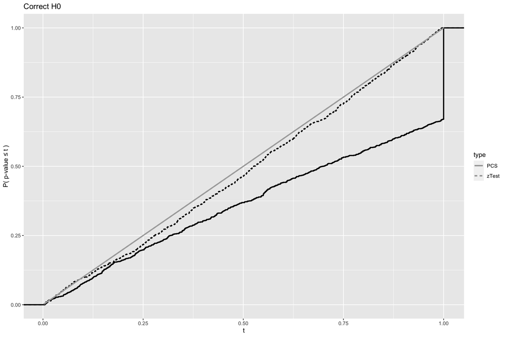

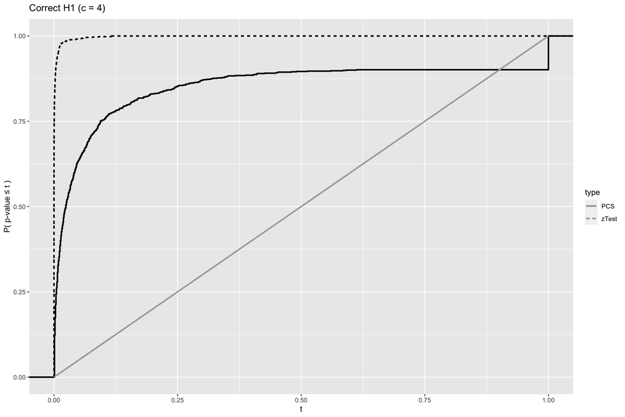

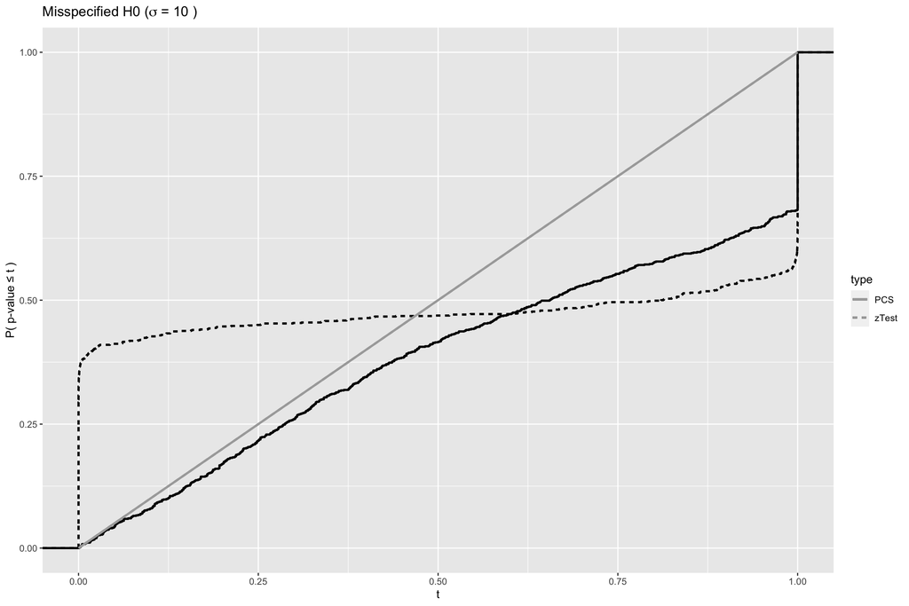

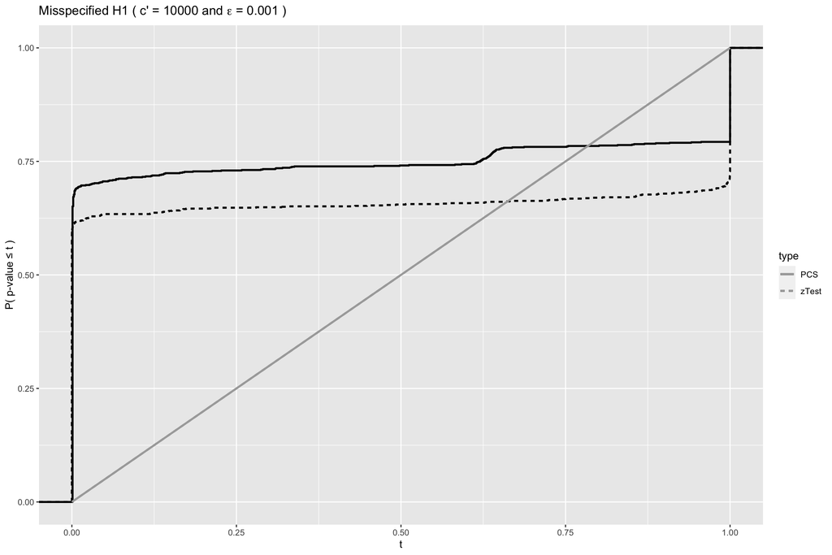

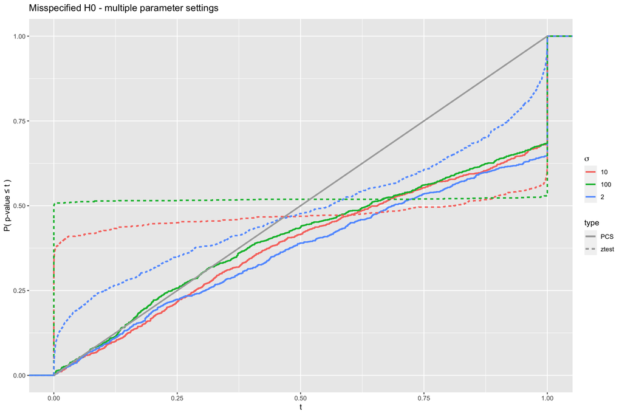

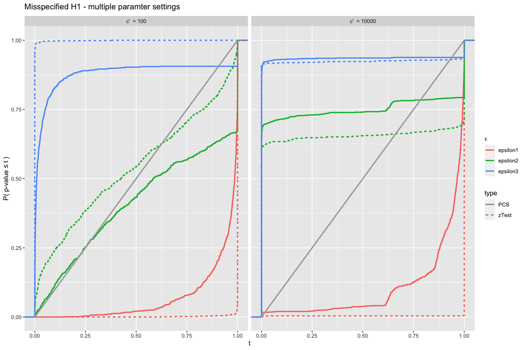